# Week 3: Generalized Linear Models

PS 818 - Data Analysis with Statistical Models

Anton Strezhnev

strezhnev@wisc.edu

University of Wisconsin-Madison

September 21, 2026

## Generalized Linear Models

## Previously

- **Likelihood**: a function of the parameters $\theta$ evaluated at the observed data

  $$\mathcal{L}(\theta| \mathbf{y}) = f(\mathbf{y}| \theta) \qquad \ell_n(\theta) = \sum_{i=1}^n \log f(y_i|\theta)$$
- **Maximum likelihood estimator**: $\hat{\theta} = \argmax_{\theta \in \Theta} \ \ell_n(\theta)$
  - **Consistent**: $\hat{\theta} \overset{p}{\to} \theta_0$
  - **Asymptotically normal**: $\sqrt{n}(\hat{\theta} - \theta_0) \overset{d}{\to} \text{Normal}\big(0, \mathcal{I}(\theta_0)^{-1}\big)$
  - **Asymptotically efficient**: attains the Cramér-Rao lower bound

## This week

- **More properties of the MLE**
  - **Invariance** and the **delta method**
- **How does numerical optimization actually work?**
  - **Newton-Raphson**, Fisher scoring, gradient ascent
- **Generalized linear models**
  - Extending the classic linear form to **functions** of the CEF
  - $g(\mathbb{E}[Y_i|X_i]) = X_i^{\prime}\beta$
- **Binary outcome models**
  - Logit and probit; deriving and estimating the likelihood
  - Interpretation: log-odds, marginal effects, and the delta method
- **An application**: propensity scores and inverse probability weighting

## More on the MLE

## Invariance

- We often want to do inference on some **function** of $\theta$
  - (e.g.) we estimate $\beta$ but want a predicted probability, a risk ratio, or a marginal effect.
- The MLE has a convenient property: **invariance**.
  - If $\hat{\theta}$ is the MLE of $\theta$, then $g(\hat{\theta})$ is the MLE of $g(\theta)$ – for *any* function $g$.
- Combined with consistency, $g(\hat{\theta}) \overset{p}{\to} g(\theta_0)$ for continuous $g$ (continuous mapping theorem).
- But how do we get the standard errors (asymptotically)?
  - The **delta method**

## Delta method

- We know the asymptotic variance of $\hat{\theta}$
  - It’s the inverse Fisher information, estimated by the inverse negative Hessian at the MLE.
- To get $\text{Var}(g(\hat{\theta}))$, start with a first-order Taylor approximation around the true value $\theta_0$

  $$g(\hat{\theta}) \approx g(\theta_0) + \big[\nabla g(\theta_0)^{\prime}\big](\hat{\theta} - \theta_0)$$
- Take the variance

  $$\text{Var}\big(g(\hat{\theta})\big) \approx \text{Var}\bigg(g(\theta_0) + \big[\nabla g(\theta_0)^{\prime}\big]\hat{\theta} - \big[\nabla g(\theta_0)^{\prime}\big]\theta_0\bigg)$$
- $g(\theta_0)$ and $\nabla g(\theta_0)$ are **constants**, so the variance of the first and third terms is zero

  $$\text{Var}\big(g(\hat{\theta})\big) \approx \text{Var}\bigg(\big[\nabla g(\theta_0)^{\prime}\big]\hat{\theta}\bigg)$$

## Delta method

- Pull out and “square” the constant. We get an expression in terms of the original variance-covariance matrix

  $$\text{Var}\big(g(\hat{\theta})\big) \approx \big[\nabla g(\theta_0)^{\prime}\big]\text{Var}(\hat{\theta})\big[\nabla g(\theta_0)\big]$$
- And so our asymptotic approximation is

  $$\sqrt{n}\big(g(\hat{\theta}) - g(\theta_0)\big) \overset{d}{\to} \text{Normal}\bigg(0, \ \big[\nabla g(\theta_0)^{\prime}\big]\mathcal{I}(\theta_0)^{-1}\big[\nabla g(\theta_0)\big]\bigg)$$
- We can use a plug-in estimator at the MLE: evaluate the gradient at $\hat{\theta}$ and use our existing estimator $\widehat{\text{Var}}(\hat{\theta})$.

## How optimizers work

## Finding the maximum

- How does `maxLik()` actually find a solution?
- Our estimator is defined as

  $$\hat{\theta} = \argmax_{\theta \in \Theta} \ \ell_n(\theta)$$
- For well-behaved problems the log-likelihood is **concave**, so finding the maximum amounts to finding the unique *solution* to $S_n(\theta) = 0$.
- Closed form solutions are rare (the Normal linear model is a special case).
  - Generally, we’ll use an *iterative* algorithm to find this solution.

## Newton-Raphson

- We start at some initial guess $\hat{\theta}^{(0)}$
- Let $\hat{\theta}^{(t)}$ denote the “current” value and $\hat{\theta}^{(t+1)}$ our update – we keep iterating until convergence.
- Our goal is to solve for a zero of $S_n(\theta)$. Take a first-order Taylor approximation around our current guess

  $$S_n(\theta) \approx S_n(\hat{\theta}^{(t)}) + \nabla S_n(\hat{\theta}^{(t)}) \left(\theta - \hat{\theta}^{(t)}\right)$$
- What’s $\nabla S_n(\hat{\theta}^{(t)})$?
  - It’s the Jacobian of the gradient… or the matrix of second-order partial derivatives of the log-likelihood… or the **Hessian** $H_n(\hat{\theta}^{(t)})$!

## Newton-Raphson

- Our next value of $\hat{\theta}$ is the value that sets this approximation to zero

  $$0 = S_n(\hat{\theta}^{(t)}) + H_n(\hat{\theta}^{(t)}) \left(\hat{\theta}^{(t+1)} - \hat{\theta}^{(t)}\right)$$
- Multiply through by the inverse Hessian and rearrange

  $$\hat{\theta}^{(t+1)} = \hat{\theta}^{(t)} - H_n^{-1}(\hat{\theta}^{(t)}) S_n(\hat{\theta}^{(t)})$$
- Recall that the **negative** Hessian at $\hat\theta$ is the **observed Fisher information** $\mathcal{J}_n(\hat\theta) = -H_n(\hat\theta)$
  - So the update is the score scaled by the inverse negative hessian.
- An alternative algorithm, **Fisher scoring**, substitutes the *expected* Fisher information $\mathcal{I}_n$ for the observed one.
  - Identical for GLMs with the canonical link – we’ll see why later.

## Gradient ascent

- Compare the Newton-Raphson update to the classic “gradient descent/gradient ascent” algorithm

  $$\hat{\theta}^{(t+1)} = \hat{\theta}^{(t)} + \gamma_t S_n(\hat{\theta}^{(t)})$$
- Gradient ascent chooses some sequence of $\gamma_t$ (the “learning rate” or “step size”) at iteration $t$
  - The gradient tells us **which direction** to move in and $\gamma_t$ tells us **how far** to move.
- Contrast with Newton-Raphson, where “how far to move” comes from computing and inverting the Hessian
  - More information per step, but each step is computationally expensive (inverting a matrix is computationally hard)
- **Trade-off**: Newton-Raphson converges quickly but each step is costly; gradient ascent steps are cheap but need more of them.
  - Also typically need to **tune** the learning rate $\gamma_t$ - too large and we **overshoot** the true optimum

## Illustration

- Let’s illustrate with a simple one-parameter likelihood.

  $$y_i \underset{\text{i.i.d}}{\sim} \text{Bernoulli}(\pi), \qquad \pi = \frac{1}{1 + \exp(-\theta)}$$
  - One parameter $\theta$, the log-odds of success.
- The **average** log-likelihood, its score, and its Hessian all have closed forms

  $$\bar{\ell}_n(\theta) = \bar{y}\,\theta - \log\big(1 + e^{\theta}\big), \qquad \bar{S}_n(\theta) = \bar{y} - \pi, \qquad \bar{H}_n(\theta) = -\pi(1-\pi)$$
- The Newton-Raphson step can be written in closed form

  $$\hat{\theta}^{(t+1)} = \hat{\theta}^{(t)} + \frac{\bar{y} - \pi^{(t)}}{\pi^{(t)}\big(1 - \pi^{(t)}\big)}$$
- And the true MLE is also known in closed form: $\hat{\theta} = \log\frac{\bar{y}}{1-\bar{y}}$

## Coding the two algorithms

- Simulate some data and write down the three components

```r
set.seed(60637)
n <- 100
y <- rbinom(n, 1, 1/(1 + exp(-0.8)))   # true theta = 0.8
ybar <- mean(y)

loglik <- function(th) ybar*th - log(1 + exp(th))      # average log-likelihood
score  <- function(th) ybar - 1/(1 + exp(-th))         # average score
hess   <- function(th){ p <- 1/(1 + exp(-th)); -p*(1-p) }  # average Hessian

theta_hat <- log(ybar/(1 - ybar))                      # the analytic MLE
theta_hat
```

```
[1] 0.895
```

## Coding the two algorithms

```r
newton <- function(th, iter){                 # step = score / curvature
  path <- th
  for (t in 1:iter){ th <- th - score(th)/hess(th); path <- c(path, th) }
  path
}
grad_ascent <- function(th, gamma, iter){     # step = score * fixed learning rate
  path <- th
  for (t in 1:iter){ th <- th + gamma*score(th); path <- c(path, th) }
  path
}
```

## Coding the two algorithms

- Start both at $\hat{\theta}^{(0)} = -1$

```r
nr_path <- newton(-1, iter = 4)
ga_path <- grad_ascent(-1, gamma = 1, iter = 12)
round(nr_path, 6)
```

```
[1] -1.000  1.243  0.863  0.895  0.895
```

```r
round(ga_path, 6)
```

```
 [1] -1.0000 -0.5589 -0.2127  0.0503  0.2477  0.3961  0.5083  0.5939  0.6597
[10]  0.7105  0.7500  0.7808  0.8049
```

- Newton-Raphson is at the MLE (0.895) by the **fourth** iteration.
- Gradient ascent has taken twelve steps and still isn’t there.

## Newton-Raphson

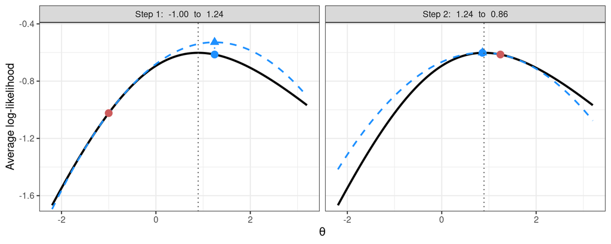

## Gradient ascent

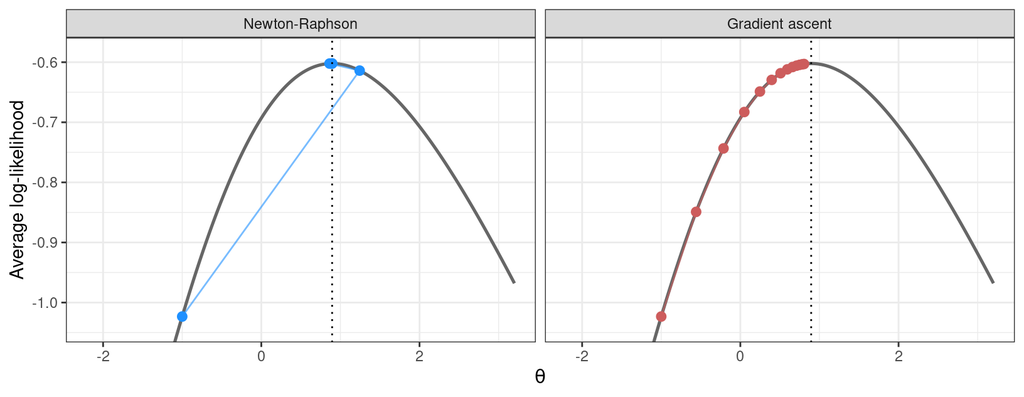

## Intro to GLMs

## Motivation: Propensity Scores

- Researchers wanting to estimate causal effects from observational designs often use a *weighting* estimator to account for non-random treatment assignment.
  - Observe treatment $D_i$, confounders $X_i$, outcome $Y_i$
  - Need to estimate the **propensity score** $\pi_i = \Pr(D_i = 1 | X_i)$ to construct “inverse propensity of treatment weights”
- **Key problem**: with many continuous covariates, it’s hard to estimate $\Pr(D_i = 1 | X_i)$ non-parametrically
  - One solution: assume a parametric *model* for $D_i$.
- Propensity scores are **predictions** from the model.

## The LaLonde dataset

- LaLonde (1986) asked: can selection-on-observables designs recover the answer from a randomized experiment?
  - The **National Supported Work Demonstration (NSW)** randomly assigned disadvantaged workers to a job training program.
  - Outcome: real earnings in 1978 (`re78`).
  - Because assignment was random, the experiment gives a **credible benchmark**: roughly **$1,794** for the subsample we’ll use (Dehejia and Wahba 1999).
- LaLonde **created** an observational dataset by replacing the experimental controls with a survey comparison group drawn from the **Panel Study of Income Dynamics** (PSID).
  - Now treatment is *not* randomly assigned – the comparison group is much older, better educated, and far richer at baseline.
  - If our adjustment methods work, they should recover something near $1,794 anyway.
- LaLonde (1986) found typical OLS regression worked poorly
  - Dehejia and Wahba (1999) tackle this with **propensity score** methods (specifically *matching*, but we’ll do weighting).

## The LaLonde dataset

- The dataset is in a lot of R packages, such as `causalsens`

```r
library(causalsens)
data(lalonde.psid)
lalonde <- lalonde.psid   # shorter name for the slides
glimpse(lalonde)
```

```
Rows: 2,675
Columns: 12
$ age       <dbl> 37, 22, 30, 27, 33, 22, 23, 32, 22, 33, 19, 21, 18, 27, 17, …
$ education <dbl> 11, 9, 12, 11, 8, 9, 12, 11, 16, 12, 9, 13, 8, 10, 7, 10, 13…
$ black     <dbl> 1, 0, 1, 1, 1, 1, 1, 1, 1, 0, 1, 1, 1, 1, 1, 1, 1, 1, 1, 1, …
$ hispanic  <dbl> 0, 1, 0, 0, 0, 0, 0, 0, 0, 0, 0, 0, 0, 0, 0, 0, 0, 0, 0, 0, …
$ married   <dbl> 1, 0, 0, 0, 0, 0, 0, 0, 0, 1, 0, 0, 0, 1, 0, 0, 0, 0, 0, 0, …
$ nodegree  <dbl> 1, 1, 0, 1, 1, 1, 0, 1, 0, 0, 1, 0, 1, 1, 1, 1, 0, 1, 0, 0, …
$ re74      <dbl> 0, 0, 0, 0, 0, 0, 0, 0, 0, 0, 0, 0, 0, 0, 0, 0, 0, 0, 0, 0, …
$ re75      <dbl> 0, 0, 0, 0, 0, 0, 0, 0, 0, 0, 0, 0, 0, 0, 0, 0, 0, 0, 0, 0, …
$ re78      <dbl> 9930, 3596, 24910, 7506, 290, 4056, 0, 8472, 2164, 12418, 81…
$ u74       <dbl> 1, 1, 1, 1, 1, 1, 1, 1, 1, 1, 1, 1, 1, 1, 1, 1, 1, 1, 1, 1, …
$ u75       <dbl> 1, 1, 1, 1, 1, 1, 1, 1, 1, 1, 1, 1, 1, 1, 1, 1, 1, 1, 1, 1, …
$ treat     <dbl> 1, 1, 1, 1, 1, 1, 1, 1, 1, 1, 1, 1, 1, 1, 1, 1, 1, 1, 1, 1, …
```

- $n = 2{,}675$: **185** NSW treated units and **2,490** PSID comparison units.

## The experimental benchmark

- The **experimental** controls are not in that dataset – LaLonde replaced them. But they ship alongside it.

```r
data(lalonde.exp)   # 185 treated + 260 *randomized* controls
lalonde.exp %>% group_by(treat) %>%
  summarize(n = n(), age = mean(age), education = mean(education),
            married = mean(married), re74 = mean(re74))
```

```
# A tibble: 2 × 6
  treat     n   age education married  re74
  <int> <int> <dbl>     <dbl>   <dbl> <dbl>
1     0   260  25.1      10.1   0.154 2107.
2     1   185  25.8      10.3   0.189 2096.
```

- Randomization did its job – the two arms look alike on every pre-treatment covariate.

```r
exp_att <- lm_robust(re78 ~ treat, data = lalonde.exp, se_type = "HC2")
coef(summary(exp_att))["treat",]
```

```
  Estimate Std. Error    t value   Pr(>|t|)   CI Lower   CI Upper         DF
  1.79e+03   6.71e+02   2.67e+00   7.77e-03   4.76e+02   3.11e+03   4.43e+02
```

- Training raised 1978 earnings by about **$1,794**. That is the number our adjustment methods have to recover.
  - The 185 treated units are the *same people* in both datasets; only the comparison group changes.
  - Note the benchmark is **itself an estimate**, with a 95% CI of roughly $[\$476,\ \$3{,}113]$.

## The naive comparison

- What happens if we just compare treated and control earnings directly?

```r
lalonde %>% group_by(treat) %>%
  summarize(n = n(), mean_re78 = mean(re78), mean_re74 = mean(re74),
            mean_age = mean(age), mean_married = mean(married))
```

```
# A tibble: 2 × 6
  treat     n mean_re78 mean_re74 mean_age mean_married
  <dbl> <int>     <dbl>     <dbl>    <dbl>        <dbl>
1     0  2490    21554.    19429.     34.9        0.866
2     1   185     6349.     2096.     25.8        0.189
```

- Complete ignorability is implausible – the PSID men are nine years older, nearly two years better educated, four times as likely to be married, and earned nine times as much in 1974.

## The naive comparison

- Regressing 1978 earnings on treatment alone:

```r
naive_fit <- lm_robust(re78 ~ treat, data=lalonde, se_type="HC2")
summary(naive_fit)
```

```
Call:
lm_robust(formula = re78 ~ treat, data = lalonde, se_type = "HC2")

Standard error type:  HC2

Coefficients:
            Estimate Std. Error t value  Pr(>|t|) CI Lower CI Upper   DF
(Intercept)    21554        312    69.1  0.00e+00    20943    22165 2673
treat         -15205        657   -23.1 3.93e-108   -16493   -13916 2673

Multiple R-squared:  0.0609 ,   Adjusted R-squared:  0.0606
F-statistic:  535 on 1 and 2673 DF,  p-value: <2e-16
```

- The training program appears to **lower** earnings by about $15,205.

## Generalized Linear Models

- Generalized linear models (GLMs) (Nelder and Wedderburn 1972) have three components:
  1. A parametric distribution for $Y_i|X_i$ (“stochastic component”)
  2. A linear predictor: $\eta_i = X_i^{\prime}\beta = \beta_0 + \beta_1X_{i1} + \beta_2X_{i2} + \dotsc + \beta_kX_{ik}$ (“systematic component”)
  3. A link function $g()$ applied to the CEF $\mathbb{E}[Y_i|X_i]$ that yields the linear predictor

     $$g\big(\mathbb{E}[Y_i | X_i]\big) = \eta_i$$
- Alternatively, we can write the CEF in terms of the “inverse link” $g^{-1}()$ applied to the linear predictor

## Exponential Family

- The types of probability distributions permitted for $Y_i$ are quite general: the **exponential family**
  - This contains the Normal as well as many other common distributions – the Bernoulli, Poisson, exponential, gamma, and more.
- Exponential family distributions have density functions of the form

  $$f(Y|\theta) = h(Y) \exp\bigg\{b(\theta) \cdot T(Y) - A(\theta)\bigg\}$$
- $h(Y)$, $b(\theta)$, $T(Y)$ and $A(\theta)$ are known functions
  - $T(Y)$ is the **sufficient statistic**, $b(\theta)$ the **canonical (natural) parameter**, $A(\theta)$ the **log-normalizer**.
- **The key intuition**: exponential family distributions factorize in a convenient way
  - The parameter and the data interact only through the product $b(\theta) \cdot T(Y)$.
  - If $b(\theta) = \theta$, the distribution is in “canonical” form.

## Example: Bernoulli

- Consider the Bernoulli PMF

  $$f(Y_i|\pi_i) = \pi_i^{Y_i}(1-\pi_i)^{1-Y_i}$$
- Take the log, then the exponent

  $$f(Y_i|\pi_i) = \exp\bigg\{\log\bigg[\pi_i^{Y_i}(1-\pi_i)^{1-Y_i}\bigg]\bigg\}$$
- Properties of logs

  $$f(Y_i|\pi_i) = \exp\bigg\{Y_i\log(\pi_i) + (1-Y_i)\log(1-\pi_i)\bigg\}$$

## Example: Bernoulli

- Rearranging and using properties of logs again

  $$f(Y_i|\pi_i) = \exp\bigg\{Y_i\log\bigg(\frac{\pi_i}{1-\pi_i}\bigg) + \log(1-\pi_i)\bigg\}$$
- So our exponential form is
  - $h(Y) = 1$
  - $T(Y) = Y_i$
  - $b(\pi_i) = \log\bigg(\frac{\pi_i}{1-\pi_i}\bigg)$
  - $A(\pi_i) = -\log(1-\pi_i)$
    - remember the exponential form carries a **minus** sign in front of $A$
- Critically, this is where we get a good link function
  - The **canonical parameter** is $\log\bigg(\frac{\pi}{1-\pi}\bigg)$ – the log-odds.
  - The **canonical link** is the function that equates this parameter with the linear predictor: $\log\bigg(\frac{\pi_i}{1-\pi_i}\bigg) = X_i^{\prime}\beta$

## Binary outcome models

## Logistic regression

- The “logit” or “logistic” GLM models the **log-odds** of a binary outcome as a function of the linear predictor $X_i^{\prime}\beta$

  $$Y_i \underset{\text{i.i.d}}{\sim} \text{Bernoulli}(\pi_i)$$

  $$\mathbb{E}[Y_i | X_i] = \Pr(Y_i = 1 | X_i) = \pi_i$$

  $$\log\bigg(\frac{\pi_i}{1-\pi_i}\bigg) = X_i^{\prime}\beta$$
- Alternatively, this is written in terms of the “inverse link” function (the logistic function) relating $\pi_i$ to $g^{-1}(X_i^{\prime}\beta)$

  $$\pi_i = \frac{\exp(X_i^{\prime}\beta)}{1 + \exp(X_i^{\prime}\beta)} = \frac{1}{1 + \exp(-X_i^{\prime}\beta)}$$

## Inverse-link functions

- The logistic function maps inputs on $\mathbb{R}$ to $(0, 1)$

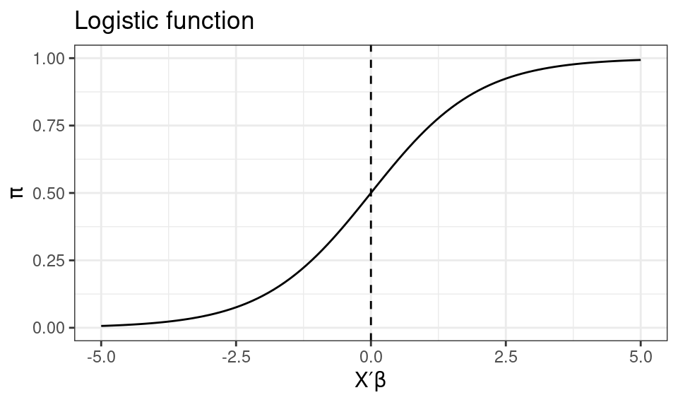

## Inverse-link functions

- Another link is the “probit”, whose inverse link is the Normal CDF $\Phi()$

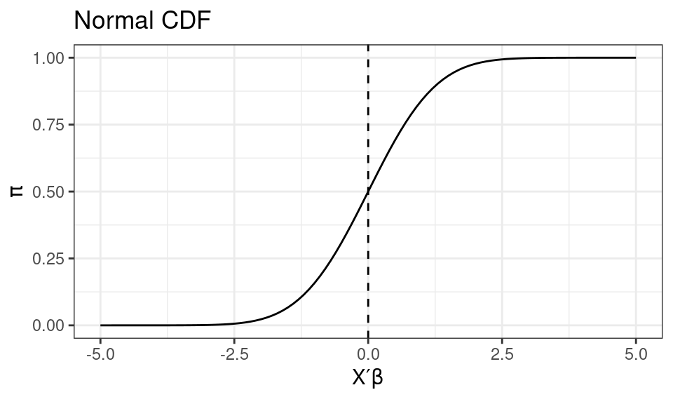

## Inverse-link functions

- When do we use probit vs. logit?
  - Computational convenience – the logit is the canonical link, so it’s better behaved.
  - Probit has some good properties for Bayesian inference (we’ll come back to this).
- Can you tell the difference?

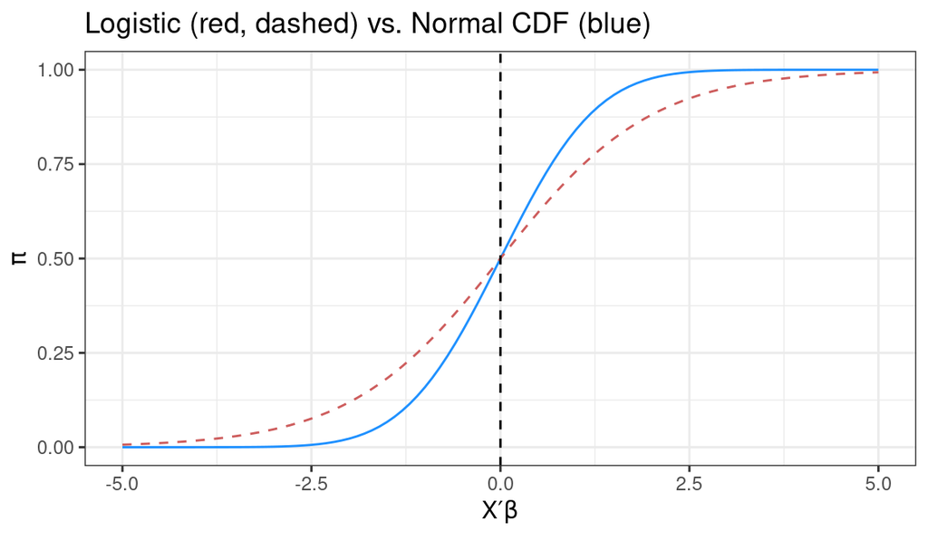

## Deriving the logit likelihood

- Start from the Bernoulli log-likelihood

  $$\ell_n(\beta) = \sum_{i=1}^n Y_i\log(\pi_i) + (1-Y_i)\log(1 - \pi_i)$$
- Collecting the $Y_i$ terms gives us the log-odds, which is just $X_i^{\prime}\beta$

  $$\ell_n(\beta) = \sum_{i=1}^n Y_i \log\bigg(\frac{\pi_i}{1-\pi_i}\bigg) + \log(1 - \pi_i)$$
- And from the inverse link,

  $$1 - \pi_i = 1 - \frac{1}{1 + \exp(-X_i^{\prime}\beta)} = \frac{\exp(-X_i^{\prime}\beta)}{1 + \exp(-X_i^{\prime}\beta)} = \frac{1}{1 + \exp(X_i^{\prime}\beta)}$$
- Substituting in

  $$\ell_n(\beta) = \sum_{i=1}^n \bigg[Y_i X_i^{\prime}\beta - \log\bigg(1 + \exp(X_i^{\prime}\beta)\bigg)\bigg]$$

## Example: Estimating the propensity score

- We want to predict assignment to training, `treat`, from the pre-treatment covariates
  - `age` - Age in years
  - `education` - Years of schooling
  - `black`, `hispanic` - Race/ethnicity indicators
  - `married` - Married; binary indicator
  - `nodegree` - No high school degree; binary indicator
  - `re74` - Real earnings in 1974 (pre-treatment)
  - `re75` - Real earnings in 1975 (pre-treatment)

## Example: Estimating the propensity score

- Make the design matrix $\mathbf{X}$

```r
X_mat <- model.matrix(treat ~ age + education + black + hispanic + married + nodegree + re74 + re75, data=lalonde)
head(X_mat) # View the top of the matrix
```

```
  (Intercept) age education black hispanic married nodegree re74 re75
1           1  37        11     1        0       1        1    0    0
2           1  22         9     0        1       0        1    0    0
3           1  30        12     1        0       0        0    0    0
4           1  27        11     1        0       0        1    0    0
5           1  33         8     1        0       0        1    0    0
6           1  22         9     1        0       0        1    0    0
```

- How many observations?

```r
n_obs <- nrow(X_mat)
n_obs
```

```
[1] 2675
```

## Example: Estimating the propensity score

```r
est <- coef(logit_mle) # Our optimization routine
names(est) <- colnames(X_mat)
est
```

```
(Intercept)         age   education       black    hispanic     married
   0.637053   -0.078996    0.039806    2.200219    2.008432   -1.627318
   nodegree        re74        re75
   0.774187   -0.000109   -0.000261
```

## Example: Estimating the propensity score

- Compare to the built-in R routine

```r
logit_Rglm <- glm(treat ~ age + education + black + hispanic + married + nodegree + re74 + re75,
                  data=lalonde, family=binomial(link="logit"))
coef(logit_Rglm)
```

```
(Intercept)         age   education       black    hispanic     married
   0.637053   -0.078996    0.039806    2.200219    2.008432   -1.627318
   nodegree        re74        re75
   0.774187   -0.000109   -0.000261
```

- Let’s obtain our (asymptotic) variance-covariance matrix – the inverse of the observed information

```r
logit_vcov <- solve(-maxLik::hessian(logit_mle))
```

- Square root of the diagonal gives our SEs

```r
logit_SEs <- sqrt(diag(logit_vcov))
```

## Example: Estimating the propensity score

- Let’s get our test statistics and p-values, using the usual asymptotic normal approximation

```r
results <- rbind(coef(logit_mle), logit_SEs,
                     coef(logit_mle)/logit_SEs,
                     2*pnorm(-abs(coef(logit_mle)/logit_SEs)))
colnames(results) <- colnames(X_mat)
rownames(results) <- c("Estimate", "Std. Error", "Test statistic", "p-value")
round(results, 4)
```

```
               (Intercept)     age education black hispanic married nodegree
Estimate             0.637 -0.0790    0.0398 2.200   2.0084  -1.627   0.7742
Std. Error           1.180  0.0148    0.0697 0.318   0.5592   0.263   0.3529
Test statistic       0.540 -5.3453    0.5709 6.915   3.5914  -6.195   2.1941
p-value              0.589  0.0000    0.5681 0.000   0.0003   0.000   0.0282
                  re74    re75
Estimate       -0.0001 -0.0003
Std. Error      0.0000  0.0000
Test statistic -3.7472 -6.4661
p-value         0.0002  0.0000
```

## Interpreting logit coefficients

- How do we interpret the $\beta$ parameters substantively?

  $$\log\bigg(\frac{\pi_i}{1-\pi_i}\bigg) = \beta_0 + \beta_1X_{i1} + \beta_2X_{i2} + \dotsc + \beta_k X_{ik}$$
- Take the partial derivative w.r.t. $X_{ik}$

  $$\frac{\partial}{\partial X_{ik}} \log\bigg(\frac{\pi_i}{1-\pi_i}\bigg) = \beta_k$$
- So $\beta_k$ captures the change in the log-odds for a one-unit change in $X_{k}$
  - Descriptively, it’s the difference in log-odds between two observations that differ in $X_{k}$ by one unit.
  - Exponentiating, $\exp(\beta_k)$ is an **odds ratio**. This is *not* a risk ratio, and it is not a difference in probabilities.

## Interpreting logit coefficients

- On the “log-odds” scale, the change due to an increase in $X_{k}$ does not depend on the values of the other $X$ variables (unless we explicitly specify an interaction).
  - But thinking on the log-odds scale is hard! We think in terms of probabilities.
  - This additivity *does not hold* when we take $\frac{\partial}{\partial X_{i1}} \pi_i$
- Working through the chain rule,

  $$\frac{\partial \pi_i}{\partial X_{ik}} = \beta_k \, \pi_i(1 - \pi_i)$$
  - The effect on the probability scale depends on $\pi_i$, and therefore on **every** covariate.
- Logit models *implicitly* encode interactions with respect to the CEF $\mathbb{E}[Y_i | X_i]$.

## Interpreting logit coefficients

- **Remember**: A one-unit change in the linear predictor corresponds to *different* changes in probability depending on your baseline.

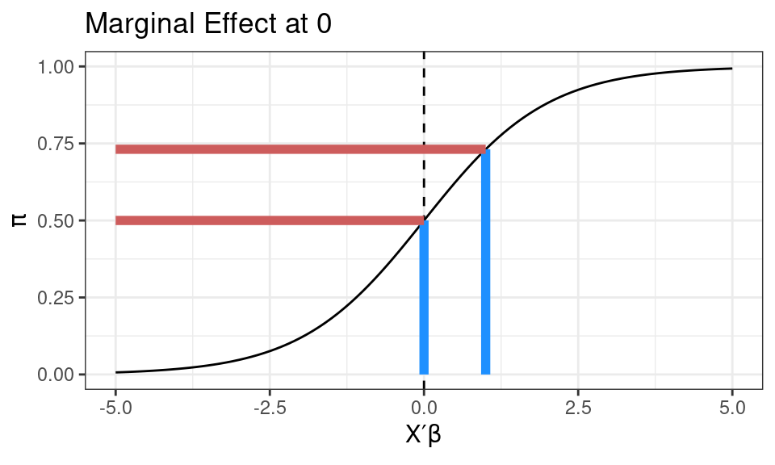

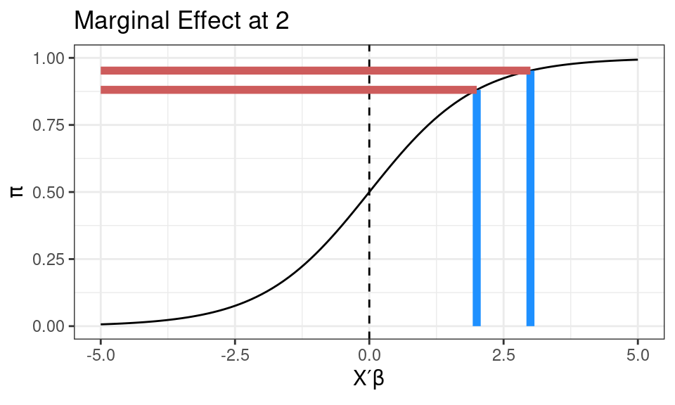

## Inference on transformations

## Transformed quantities

- We have $\hat{\beta}$, but we actually want the **propensity score** $\hat{\pi}_i = \Pr(D_i = 1 | X_i)$
  - Just apply the inverse link to get the quantity we want

  $$\hat{\pi}_i = \frac{1}{1 + \exp(-X_i^{\prime}\hat{\beta})}$$
- By **invariance**, this is the MLE of $\pi_i$, and it’s consistent for the true propensity score (under our modeling assumptions).
- But if we want a confidence interval for $\hat{\pi}_i$, we use the **delta method**.

## Example: a predicted propensity

- Let’s get the propensity of receiving training for a **typical NSW participant** – the median covariate profile among the treated

```
(Intercept)         age   education       black    hispanic     married
          1          25          11           1           0           0
   nodegree        re74        re75
          1           0           0
```

- Construct our prediction function

```
      [,1]
[1,] 0.888
```

## Example: a predicted propensity

- Let’s do the gradient numerically (we could calculate it analytically though!)
- Applying the delta method
- Making our 95% asymptotic CI for $\hat{\pi}(X)$

```
[1] 0.838 0.939
```

## `marginaleffects`

- The `marginaleffects` R package provides a straightforward implementation of the delta method for a lot of transformed quantities
  - (e.g.) the marginal change in the **probability of** $D_i=1$ for a one-unit change in $X$
- `avg_predictions()` will calculate point estimates + CIs for the expected outcome just like we did above.
- `avg_comparisons()` will do the implied “marginal effects” for a unit change in $X$ given a set baseline.
- We have to tell it **which covariate profile** to evaluate at. We’ll use the **treated** units – the NSW participants are the group we care about.

```r
library(marginaleffects)
treated <- subset(lalonde, treat == 1)

grid_median <- datagrid(model = logit_Rglm, newdata = treated,
                        FUN_numeric = median, FUN_integer = median, FUN_binary = median)
grid_mean   <- datagrid(model = logit_Rglm, newdata = treated,
                        FUN_numeric = mean,   FUN_integer = mean,   FUN_binary = mean)
```

## `marginaleffects`

- The **median** profile is the one we just built by hand; the **mean** profile is the other common convention

```r
rbind(median = unlist(grid_median[, -1]), mean = unlist(grid_mean[, -1]))
```

```
        age black education hispanic married nodegree re74 re75
median 25.0 1.000      11.0   0.0000   0.000    1.000    0    0
mean   25.8 0.843      10.3   0.0595   0.189    0.708 2096 1532
```

- Note the mean profile is not a person anyone could be – it is 84% Black and 71% without a degree.
  - The median profile at least corresponds to a *possible* respondent.

## `marginaleffects`: predicted propensity

```r
avg_predictions(logit_Rglm, newdata = grid_median)   # matches our hand calculation
```

```
 Estimate Std. Error    z Pr(>|z|)     S 2.5 % 97.5 %
    0.888     0.0258 34.4   <0.001 859.9 0.838  0.939

Type: response
```

```r
avg_predictions(logit_Rglm, newdata = grid_mean)
```

```
 Estimate Std. Error    z Pr(>|z|)     S 2.5 % 97.5 %
    0.645     0.0342 18.8   <0.001 260.6 0.578  0.712

Type: response
```

- Evaluating at the *mean* moves us from $\hat{\pi} \approx 0.89$ down to $\approx 0.64$ – the profile is different, so the point on the curve is different.

## `marginaleffects`: marginal effect of `married`

```r
avg_comparisons(logit_Rglm, variables = "married", newdata = grid_median)
```

```
 Estimate Std. Error     z Pr(>|z|)    S  2.5 % 97.5 %
   -0.278     0.0612 -4.55   <0.001 17.5 -0.398 -0.158

Term: married
Type: response
Comparison: 1 - 0
```

```r
avg_comparisons(logit_Rglm, variables = "married", newdata = grid_mean)
```

```
 Estimate Std. Error     z Pr(>|z|)    S  2.5 % 97.5 %
   -0.385     0.0566 -6.81   <0.001 36.5 -0.496 -0.274

Term: married
Type: response
Comparison: 1 - 0
```

- Being married lowers the probability of NSW participation by **28** points at the median profile, **39** at the mean profile.
  - Same $\hat{\beta}$, same data – only the baseline $\pi_i$ differs. This is the $\beta_k\pi_i(1-\pi_i)$ scaling at work.

## Inverse propensity of treatment weighting

- Now we have $\hat{\pi}_i$ for every unit.
- The control group is unrepresentative of the treated group.
  - So we **reweight** it. Upweight controls who look like treated units; downweight the ones who don’t.
- Under **conditional ignorability** ($\{Y_i(1), Y_i(0)\} \perp D_i \mid X_i$) and **positivity** ($0 < \pi_i < 1$), the IPTW estimator identifies a causal contrast (Rosenbaum and Rubin 1983).
- For the **average treatment effect on the treated** (ATT), the weights are

  $$w_i = D_i + (1 - D_i)\frac{\hat{\pi}_i}{1 - \hat{\pi}_i}$$
  - Treated units get weight 1 – we keep the treated sample as-is and re-weight controls to match.
  - Controls get the **odds** of treatment: a control who looked very likely to be treated counts for more.

## Inverse propensity of treatment weighting

- The ATT estimator is then a difference of weighted means

  $$\widehat{\text{ATT}} = \frac{1}{n_1}\sum_{i: D_i = 1} Y_i \ - \ \frac{\sum_{i: D_i = 0} w_i Y_i}{\sum_{i: D_i = 0} w_i}$$
- Dividing by the **sum of weights** rather than $n_0$ gives the *Hájek* (stabilized) estimator
- For the **ATE** instead, we would weight *every* unit by the inverse probability of the treatment it actually received

  $$w_i^{\text{ATE}} = \frac{D_i}{\hat{\pi}_i} + \frac{1 - D_i}{1 - \hat{\pi}_i}$$
- We’ll target the ATT, since that’s what the experimental benchmark of $1,794 estimates.

## Checking overlap first

- Before weighting anything, look at the estimated propensity scores by treatment status

```r
lalonde$pscore <- as.vector(pred_prob(coef(logit_mle), X_mat))
```

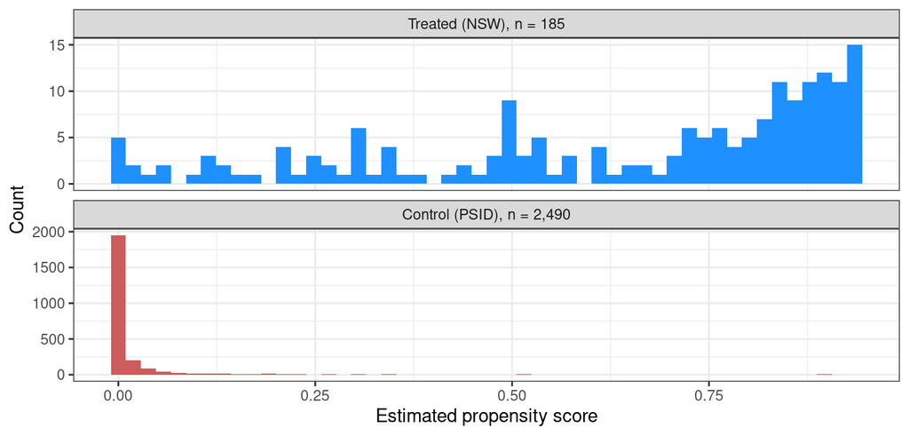

- A large mass of PSID controls has $\hat\pi \approx 0$, not close to the treated group.

## Checking overlap first

- Effectively, weighting **discards** most of the PSID sample.

```r
lalonde$w_att <- with(lalonde, ifelse(treat == 1, 1, pscore/(1 - pscore)))
c(max_control_weight = max(lalonde$w_att[lalonde$treat==0]),
  sum_control_weights = sum(lalonde$w_att[lalonde$treat==0]))
```

```
 max_control_weight sum_control_weights
               10.8               184.2
```

## Did the weights fix the imbalance?

- The point of the weights is **balance**. After weighting, the covariate distributions should look alike.
- The standard diagnostic is the **standardized mean difference**

  $$\text{SMD}_k = \frac{\bar{X}_{k,\text{treated}} - \bar{X}_{k,\text{control}}^{\,w}}{s_{k,\text{treated}}}$$
  - Scaling by the treated-group SD puts every covariate on a common, unit-free scale.
  - Common heuristic for observational studies (from biostats/epi): $|\text{SMD}| < 0.1$ is “balanced.”
- The `cobalt` package does this.

## Did the weights fix the imbalance?

```r
library(cobalt)
bt <- bal.tab(treat ~ age + education + black + hispanic + married + nodegree + re74 + re75,
              data = lalonde, weights = lalonde$w_att,
              method = "weighting", estimand = "ATT",
              un = TRUE, binary = "std", thresholds = c(m = .1))
bt$Balance
```

```
             Type Diff.Un Diff.Adj        M.Threshold
age       Contin.  -1.263  0.09045     Balanced, <0.1
education Contin.  -0.881  0.00646     Balanced, <0.1
black      Binary   1.630 -0.02417     Balanced, <0.1
hispanic   Binary   0.114 -0.02169     Balanced, <0.1
married    Binary  -1.729  0.07538     Balanced, <0.1
nodegree   Binary   0.886 -0.04782     Balanced, <0.1
re74      Contin.  -3.547 -0.10173 Not Balanced, >0.1
re75      Contin.  -5.446 -0.06331     Balanced, <0.1
```

## Did the weights fix the imbalance?

- And the **effective sample sizes**:

```r
bt$Observations
```

```
           Control Treated
Unadjusted  2490.0     185
Adjusted      42.6     185
```

- The unweighted imbalances are enormous – `re74` starts at $-3.5$ standard deviations, `married` at $-1.7$.
  - After weighting nearly everything is inside or roughly at the $0.1$ band.
- **Note the effective sample size**: the 2,490 controls are worth about **43** after weighting.
  - This is what our histogram shows - weighting puts a large amount of weight on a small number of units.
  - Low effective sample size = higher variance estimator.
- Don’t forget that we by definition can’t check balance on things we **didn’t** control for.
  - Balance on the covariates we *included* says nothing about the confounders we omitted.

## The Love plot

- Common to present this in a **Love plot**

```r
love.plot(treat ~ age + education + black + hispanic + married + nodegree + re74 + re75,
          data = lalonde, weights = lalonde$w_att,
          method = "weighting", estimand = "ATT",
          binary = "std", thresholds = c(m = .1),
          var.names = c(age = "Age", education = "Years of education", married = "Married",
                        nodegree = "No HS degree", re74 = "Earnings 1974",
                        re75 = "Earnings 1975", black = "Black", hispanic = "Hispanic"),
          sample.names = c(Unadjusted = "Unweighted", Adjusted = "IPTW (ATT)"),
          colors = c("indianred", "dodgerblue"), shapes = c("circle", "triangle"),
          title = "Covariate balance before and after weighting")
```

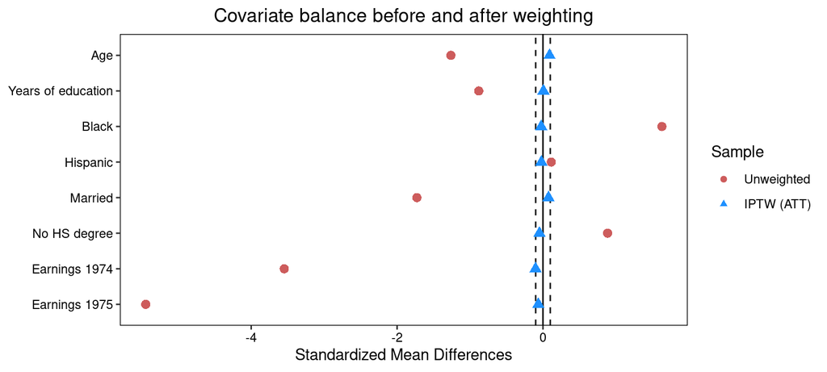

- Red circles are the unweighted sample, blue triangles the weighted one. Dashed lines mark $\pm 0.1$.

## The IPTW estimate

- Now compute the weighted difference in means

```r
att_hajek <- with(lalonde,
  mean(re78[treat == 1]) - weighted.mean(re78[treat == 0], w_att[treat == 0]))
att_hajek
```

```
[1] 1759
```

## The IPTW estimate

- Equivalently, as a weighted least squares regression

```r
summary(lm_robust(re78 ~ treat, data = lalonde, weights = w_att, se_type = "HC2"))
```

```
Call:
lm_robust(formula = re78 ~ treat, data = lalonde, weights = w_att,
    se_type = "HC2")

Weighted, Standard error type:  HC2

Coefficients:
            Estimate Std. Error t value Pr(>|t|) CI Lower CI Upper   DF
(Intercept)     4590        724    6.34 2.75e-10   3169.8     6011 2673
treat           1759        927    1.90 5.79e-02    -58.9     3577 2673

Multiple R-squared:  0.0144 ,   Adjusted R-squared:  0.014
F-statistic:  3.6 on 1 and 2673 DF,  p-value: 0.0579
```

## The IPTW estimate

- Compare to the alternatives:

```r
naive_est <- with(lalonde, mean(re78[treat==1]) - mean(re78[treat==0]))
reg_fit <- lm_robust(re78 ~ treat + age + education + black + hispanic + married + nodegree + re74 + re75,
                     data=lalonde, se_type="HC2")
reg_est <- coef(reg_fit)["treat"]
data.frame(estimator = c("Naive difference", "Regression adjustment", "IPTW (ATT)", "Experimental benchmark"),
           estimate  = c(naive_est, as.numeric(reg_est), att_hajek, coef(exp_att)["treat"]))
```

```
               estimator estimate
1       Naive difference   -15205
2  Regression adjustment      752
3             IPTW (ATT)     1759
4 Experimental benchmark     1794
```

## Estimating the standard errors

- For the standard errors, we want to account for estimation uncertainty in the propensity scores.
- Two options:
  - **Bootstrap** the whole procedure – refit the logit *inside* each bootstrap iteration.
  - Stack the score functions of both stages and apply the **sandwich estimator**
- We’ll implement the bootstrap

```r
att_fn <- function(dd){
  Xb <- model.matrix(treat ~ age + education + black + hispanic + married + nodegree + re74 + re75, data=dd)
  fit <- suppressWarnings(glm.fit(Xb, dd$treat, family = binomial()))
  ps <- as.vector(1/(1 + exp(-Xb %*% fit$coefficients)))
  w  <- ifelse(dd$treat == 1, 1, ps/(1 - ps))
  mean(dd$re78[dd$treat == 1]) - weighted.mean(dd$re78[dd$treat == 0], w[dd$treat == 0])
}
set.seed(53703)
boot_att <- replicate(2000, att_fn(lalonde[sample(nrow(lalonde), replace = TRUE),]))
c(bootstrap_SE = sd(boot_att), quantile(boot_att, c(.025, .975)))
```

```
bootstrap_SE         2.5%        97.5%
         966         -170         3599
```

## Results

- Collect the four estimators, each with its own standard error

```r
grab <- function(f) coef(summary(f))["treat", c("Estimate", "Std. Error", "CI Lower", "CI Upper")]
results_tab <- data.frame(
  estimator = c("Naive difference", "Regression adjustment", "IPTW (ATT)", "Experimental benchmark"),
  rbind(grab(naive_fit), grab(reg_fit),
        c(att_hajek, sd(boot_att), unname(quantile(boot_att, c(.025, .975)))),
        grab(exp_att)),
  se = c("HC2", "HC2", "bootstrap", "HC2"),
  row.names = NULL)
names(results_tab) <- c("estimator", "estimate", "std_error", "ci_lower", "ci_upper", "se_type")
```

## Results

```r
results_tab
```

```
               estimator estimate std_error ci_lower ci_upper   se_type
1       Naive difference   -15205       657   -16493   -13916       HC2
2  Regression adjustment      752       785     -788     2292       HC2
3             IPTW (ATT)     1759       966     -170     3599 bootstrap
4 Experimental benchmark     1794       671      476     3113       HC2
```

- Adjustment moved us an enormous distance: $-\$15{,}205 \rightarrow +\$1{,}759$, against a benchmark of $\$1{,}794$.
  - Regression adjustment alone only reaches about $+\$752$
- But the bootstrap interval is **wide** and includes zero.
  - With the comparison group weighted down to an effective 43 units, there simply isn’t much information left.
- IPTW estimators are **extremely noisy** when propensities are close to $0$ or $1$.
  - **Doubly-robust** approaches (e.g. AIPW) combine the weights with an outcome model, which helps reduce variance (Kang and Schafer 2007).

## Next week

- **Latent variables and discrete choice**
  - The latent-variable representation of logit and probit
  - **Ordinal** logit and proportional odds; **multinomial** logit and IIA
- **Random utility and conditional logit**
  - Modelling the attributes of the *choices*
  - Analyzing “conjoint” experiments with model-based approaches.
- **Duration models**
  - The survival function, the hazard, and censoring
  - Parametric (exponential, Weibull), semi-parametric (Cox), and non-parametric (Kaplan-Meier) approaches
- **Readings:** Chapter 15 of Gelman et al. (2020); Clark et al. (2003); Stensrud and Hernán (2020)

## References

Clark, Taane G., Michael J. Bradburn, Sharon B. Love, and Douglas G. Altman. 2003. “Survival Analysis Part I: Basic Concepts and First Analyses.” *British Journal of Cancer* 89 (2): 232–38. https://doi.org/10.1038/sj.bjc.6601118.

Dehejia, Rajeev H., and Sadek Wahba. 1999. “Causal Effects in Nonexperimental Studies: Reevaluating the Evaluation of Training Programs.” *Journal of the American Statistical Association* 94 (448): 1053–62. https://doi.org/10.1080/01621459.1999.10473858.

Gelman, Andrew, Jennifer Hill, and Aki Vehtari. 2020. *Regression and Other Stories*. Cambridge University Press. https://avehtari.github.io/ROS-Examples/index.html.

Kang, Joseph D. Y., and Joseph L. Schafer. 2007. “Demystifying Double Robustness: A Comparison of Alternative Strategies for Estimating a Population Mean from Incomplete Data.” *Statistical Science* 22 (4): 523–39. https://doi.org/10.1214/07-STS227.

LaLonde, Robert J. 1986. “Evaluating the Econometric Evaluations of Training Programs with Experimental Data.” *American Economic Review* 76 (4): 604–20.

Nelder, John A., and Robert W. M. Wedderburn. 1972. “Generalized Linear Models.” *Journal of the Royal Statistical Society, Series A* 135 (3): 370–84. https://doi.org/10.2307/2344614.

Rosenbaum, Paul R., and Donald B. Rubin. 1983. “The Central Role of the Propensity Score in Observational Studies for Causal Effects.” *Biometrika* 70 (1): 41–55. https://doi.org/10.1093/biomet/70.1.41.

Stensrud, Mats J., and Miguel A. Hernán. 2020. “Why Test for Proportional Hazards?” *JAMA* 323 (14): 1401–2. https://doi.org/10.1001/jama.2020.1267.